# Assignment 1

##Fernando Colugnati

This is the first peer reviewed assignement for the “Reproducible Research” at Coursera, January, 2015.

##Loading and preprocessing the data Just unziped and loaded data using simple read.cvs function. Also, packages that should be installed are listed. In some tests I could not point the mirror correctely, resulting error.

```r
#Read the file
unzip("activity.zip")
a<-read.csv("activity.csv")

#Install packages
#install.packages("plyr")
#install.packages("Hmisc")
#install.packages("doBy")
```

##What is mean total number of steps taken per day?

Fisrts table presents simple statistics for the whole dataset, and also descritptivestatistics for the total number of steps in each day.

```r
#summarizes dataset and shows statistics for daily steps
summary(a)
```

```
##      steps                date          interval
##  Min.   :  0.00   2012-10-01:  288   Min.   :   0.0
##  1st Qu.:  0.00   2012-10-02:  288   1st Qu.: 588.8
##  Median :  0.00   2012-10-03:  288   Median :1177.5
##  Mean   : 37.38   2012-10-04:  288   Mean   :1177.5
##  3rd Qu.: 12.00   2012-10-05:  288   3rd Qu.:1766.2
##  Max.   :806.00   2012-10-06:  288   Max.   :2355.0
##  NA's   :2304     (Other)   :15840
```

```r
desc <- summary(tapply(a$steps, a$date, sum))
ldesc <- summary(tapply(log(a$steps+1), a$date, sum))
desc
```

```
##    Min. 1st Qu.  Median    Mean 3rd Qu.    Max.    NA's
##      41    8841   10760   10770   13290   21190       8
```

```r
ldesc
```

```
##    Min. 1st Qu.  Median    Mean 3rd Qu.    Max.    NA's
##   5.724 295.900 354.600 332.800 391.000 505.200       8
```

The mean and median for the total daily steps are 1.077 × 10<sup>4</sup> and 1.076 × 10<sup>4</sup>, respectively. Also, the log of the same variable plus one is described.

Histograms bellow presents the distribution for the total number of daily steps.

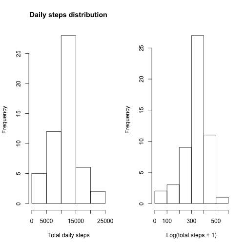

```r
par(mfrow = c(1, 2))
hist(tapply(a$steps, a$date, sum), main="Daily steps distribution", xlab="Total daily steps")
hist(tapply(log(a$steps+1), a$date, sum), main=" ", xlab="Log(total steps + 1)")
```